# Quantitative Genetics

GxE interaction – FW Regression

Felipe Ferrão

University of Florida

**Objectives:**

- 60 minutes of hands-on
- GxE interaction

**Extra information**

- [PCB 6555 – Website](https://lfelipe-ferrao.github.io/class/quantGenetic/)
- About the [author](https://lfelipe-ferrao.github.io/)
- About the [UF/IFAS Plant Breeding](https://programs.ifas.ufl.edu/plant-breeding/)

# Finlay and Wilkinson Regression

An attractive alternative to study the GxE interaction is to extend the ANOVA models by incorporating terms that explain as much as possible of the interaction. To this end, a popular method in the plant breeding literature uses regression on the mean model. [Finlay and Wilkinson (1963)](http://www.publish.csiro.au/cp/AR9630742) regression describes GxE interaction as a regression line on the environmental quality.

The Finlay–Wilkinson regression requires regressing the observed phenotypes of the line on environment effects. In the absence of explicit environmental information, the biological quality of an environment can be reflected in the average performance of all genotypes in that environment. Good environments will have a high average genotypic performance, and bad environments will have a low average genotypic performance. Thus, the GxE part is then described by a regression slopes on the environmental quality, as:

$$y_{ijk} = \mu + g_i + \hat{h}_j +
b_i\hat{h}_j + \epsilon_{ijk}$$

In short, regression on the mean model describes GxE in terms of parameters that can be given some biological meaning, including to central concepts of **adaptability** and **stability** – or in another words, **broad** and **specific** adaptation.

- Stability: genotypes with high mean (intercept) and $b_i=1$; it represents a group of genotypes that respond satisfactorily in all environmental conditions. Ex: some potato breeding programs in US that is looking for genotypes with broad adaptation.
- Low adaptability: high means and $b_i> 1$; it represents a group of genotypes that present differential responses for favorable environments. In the case of plants, such materials are considered with high risk for cultivation in places with low technology and therefore with unfavorable environmental condictions.
- High adaptability: high means and $b_i< 1$; it represents a group of genotypes that present differential responses for unfavorable environments. The fact that such genotypes maintain high performance even in unfavorable environments makes them as rustic or robust materials. In general, such genotypes are not recommended for high-tech regions.

**Advantages**

- Straightforward implementation
- Easy interpretation with some biological meaning
- Popular among breeders
- Can be expanded in multiple directions. For example:
  - [Piepho et al., 2024](https://onlinelibrary.wiley.com/doi/full/10.1111/pbr.13130) recently expanded it to account environmental covariables. Under a different perspective
  - [Lian and de los Campos, 2016](https://academic.oup.com/g3journal/article/6/3/589/6031117) incorporated relationship and covariance structure into a Bayesian format

**Drawbacks**

- Suffers from the fact that the environmental characterization is based on a single dimension.
- Environmental quality can be hard to summarize within a single explanatory variable and hence a substantial amount of GxE can remain unexplained.

# Hands on

For the sequence of this section, we will explore FW regression from different perspectives using different software. The goal is to show how such model can be fitted under different perspectives.

## Data set

- Coffee data set
- 12 environments (combination of 3 locations and seasons)
- 27 genotypes (coffee cultivars) evaluated in RBD with 3 repetitions and 5 plants per plot
- Yield (bags per hectare) collected.
- [Link for the Ferrao et al., (2024) paper](https://acsess.onlinelibrary.wiley.com/doi/10.1002/csc2.21298)
- Goals:
  - Paper described the evaluation of *Coffea canephora* (Robusta coffee) under alternative environments – sites reported in the paper are located in high altitudes, that are not the best condictions for this type of coffee.
  - Objective 1: check the general performance and the plasticity of Robusta coffee
  - Objective 2: identify adaptable and stabe genotypes

## statgenGxE R package

- [Link](https://biometris.github.io/statgenGxE/articles/statgenGxE.html#fw) for the package

The package will fit the model as:

$$y_ij{} = \mu + G_i +\beta_i E_j +
e_{ij}$$

From this model, there are some important outputs. First, when framed as an ANOVA model, we would like to see (i) if the environments are statiscally different; (ii) if we have diversity among the genotypes; and (iii) differences across the sensibilities metric.

Below, the codes:

```r
# ANOVA results
#install.packages("statgenGxE")
library(statgenGxE)
library(openxlsx)
df = read.xlsx("/Users/lferrao/UFL Dropbox/Luis Ferrao/classes/QuantGen_24/Class11_GxE/coffee_27ind_canephora_12env.xlsx")
dropsTD <- statgenSTA::createTD(data = df, genotype = "id", trial = "ENV")
dropsFW <- gxeFw(TD = dropsTD, trait = "YIELD")
dropsFW$anova
```

```
##                 Df Sum Sq Mean Sq F value    Pr(>F)
## Trial           11 294595 26781.3 81.7562 < 2.2e-16 ***
## Genotype        26  39193  1507.4  4.6018 3.721e-13 ***
## Sensitivities   26  24443   940.1  2.8700 2.377e-06 ***
## Residual      1139 373109   327.6
## Total         1202 731340   608.4
## ---
## Signif. codes:  0 '***' 0.001 '**' 0.01 '*' 0.05 '.' 0.1 ' ' 1
```

From the output, we can see that we have variation from all the source of variations !

The next step is to check the sensibilities, that is measured as the slope of the regression. It is very important to understand how the FW model have been parametrized and define how we will interpret adaptability and stability.

From the `statgenGxE` package, the slope is computed using fixed linear models and genotypes are ranked based on the sensibility values. The lowest values (closer to zero) are indicating less sensibility to environmental changes, and therefore broad adaptability. This is not difficult to be observed in the plot. If we check the genotype `CC22` and `CC17` slopes are close to zero, that indicate similar performance across all the environments.

```r
dropsFW$estimates
```

```
##    Genotype  GenMean SE_GenMean Rank      Sens   SE_Sens MSdeviation
## 8      CC16 48.83101   2.686709    1 1.5401518 0.1719336    253.7435
## 13     CC20 41.98651   2.686709    2 1.5196113 0.1719336    321.2701
## 26      CC8 49.70103   2.686709    3 1.3666983 0.1719336    290.7894
## 24      CC6 35.15021   2.749787    4 1.2588271 0.1725961    315.1590
## 16     CC23 41.31757   2.686709    5 1.2276160 0.1719336    337.3224
## 7      CC15 51.33068   2.686709    6 1.1901380 0.1719336    378.9500
## 23      CC5 39.54396   2.686709    7 1.1714295 0.1719336    183.5793
## 14     CC21 39.15517   2.686709    8 1.1354480 0.1719336    151.1186
## 12      CC2 39.95158   2.686709    9 1.1339699 0.1719336    330.4041
## 20     CC27 40.66515   2.716640   10 1.1332503 0.1728943    310.7977
## 19     CC26 37.23924   2.686709   11 1.0944950 0.1719336    296.8645
## 27      CC9 41.68454   2.716921   12 1.0610854 0.1759954    312.9804
## 5      CC13 46.75933   2.686709   13 1.0581475 0.1719336    451.3495
## 22      CC4 41.81369   2.686709   14 1.0357577 0.1719336    338.9825
## 4      CC12 47.76585   2.686709   15 1.0355826 0.1719336    382.6585
## 11     CC19 37.93937   2.686709   16 1.0298622 0.1719336    172.7439
## 2      CC10 54.61938   2.686709   17 1.0276497 0.1719336    448.2425
## 18     CC25 39.12836   2.686709   18 0.9709923 0.1719336    375.8230
## 1       CC1 39.42440   2.783119   19 0.9643602 0.1728106    372.0631
## 6      CC14 43.41910   2.686709   20 0.8836332 0.1719336    305.3907
## 21      CC3 30.03968   2.686709   21 0.7474220 0.1719336    287.0867
## 3      CC11 50.41410   2.686709   22 0.6796358 0.1719336    442.3491
## 17     CC24 38.59684   2.686709   23 0.6480260 0.1719336    192.3291
## 25      CC7 42.81098   2.686709   24 0.6411322 0.1719336    319.5585
## 10     CC18 40.66943   2.788111   25 0.5790203 0.1759414    322.9484
## 9      CC17 42.55591   2.686709   26 0.4112096 0.1719336    605.1567
## 15     CC22 31.05498   2.749787   27 0.3782103 0.1725961    177.2843
```

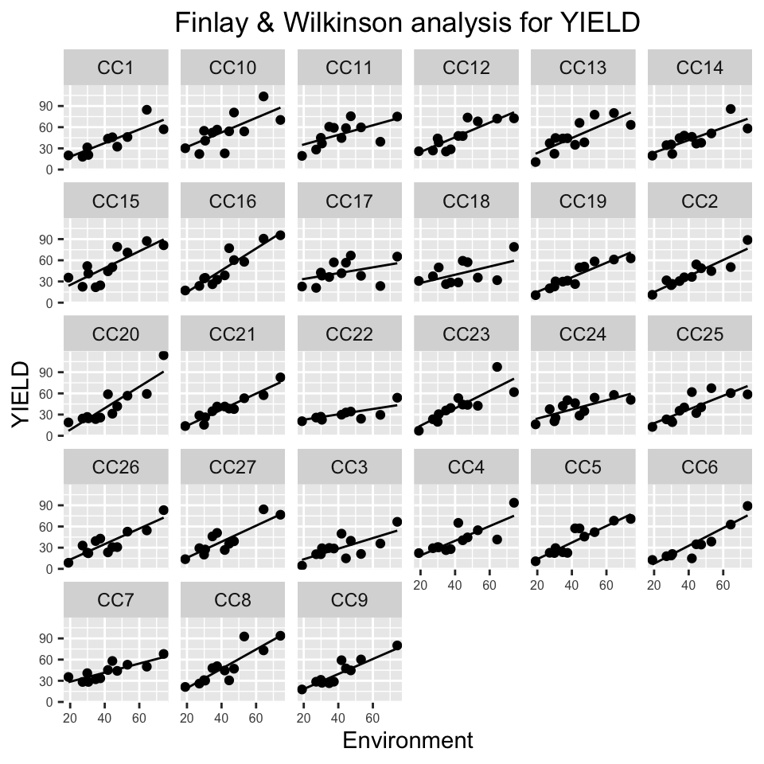

```r
plot(dropsFW, plotType = "trellis")
```

Informally, we can compute a confidence interval and check for statistical evidences if the slope is null. Below the codes.

```r
coefficients = dropsFW$estimates$Sens
standard_errors = dropsFW$estimates$SE_Sens

# Define the confidence level and critical value (z-score)
confidence_level <- 0.99
z <- qnorm((1 + confidence_level) / 2)

# Compute confidence intervals
lower_bound <- coefficients - z * standard_errors
upper_bound <- coefficients + z * standard_errors

# Combine into a data frame for better readability
conf_intervals <- data.frame(
  geno = dropsFW$estimates$Genotype,
  Estimate = coefficients,
  StdError = standard_errors,
  Lower = lower_bound,
  Upper = upper_bound
)

print(conf_intervals)
```

```
##    geno  Estimate  StdError       Lower     Upper
## 1  CC16 1.5401518 0.1719336  1.09728020 1.9830235
## 2  CC20 1.5196113 0.1719336  1.07673968 1.9624830
## 3   CC8 1.3666983 0.1719336  0.92382671 1.8095700
## 4   CC6 1.2588271 0.1725961  0.81424886 1.7034053
## 5  CC23 1.2276160 0.1719336  0.78474439 1.6704877
## 6  CC15 1.1901380 0.1719336  0.74726633 1.6330096
## 7   CC5 1.1714295 0.1719336  0.72855788 1.6143011
## 8  CC21 1.1354480 0.1719336  0.69257634 1.5783196
## 9   CC2 1.1339699 0.1719336  0.69109830 1.5768416
## 10 CC27 1.1332503 0.1728943  0.68790402 1.5785966
## 11 CC26 1.0944950 0.1719336  0.65162340 1.5373667
## 12  CC9 1.0610854 0.1759954  0.60775136 1.5144195
## 13 CC13 1.0581475 0.1719336  0.61527584 1.5010191
## 14  CC4 1.0357577 0.1719336  0.59288609 1.4786294
## 15 CC12 1.0355826 0.1719336  0.59271094 1.4784542
## 16 CC19 1.0298622 0.1719336  0.58699061 1.4727339
## 17 CC10 1.0276497 0.1719336  0.58477807 1.4705213
## 18 CC25 0.9709923 0.1719336  0.52812069 1.4138640
## 19  CC1 0.9643602 0.1728106  0.51922972 1.4094907
## 20 CC14 0.8836332 0.1719336  0.44076153 1.3265048
## 21  CC3 0.7474220 0.1719336  0.30455038 1.1902937
## 22 CC11 0.6796358 0.1719336  0.23676413 1.1225074
## 23 CC24 0.6480260 0.1719336  0.20515439 1.0908977
## 24  CC7 0.6411322 0.1719336  0.19826057 1.0840038
## 25 CC18 0.5790203 0.1759414  0.12582520 1.0322154
## 26 CC17 0.4112096 0.1719336 -0.03166199 0.8540813
## 27 CC22 0.3782103 0.1725961 -0.06636790 0.8227885
```

A simple way to take decisions is by combining both information in the same plot. If breeders are looking for more responsive genotypes, they should look for materials at the top right (for example CC16 and CC15). If they are looking for individuals with a broad adaptability, the genotype CC17 seems a good candidate.

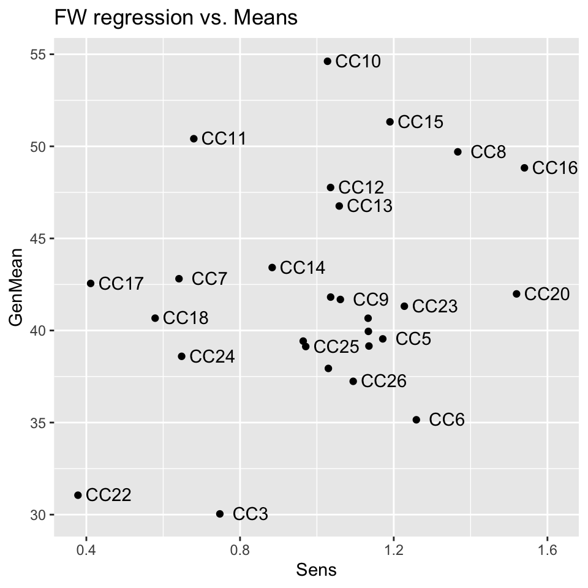

```r
library(ggplot2)
tmp = dropsFW$estimates
ggplot(tmp, aes(x=Sens, y=GenMean)) +
  geom_point() + # Show dots
  geom_text(
    label=tmp$Genotype,
    nudge_x = 0.08, nudge_y = 0.04,
    check_overlap = T
  ) + ggtitle("FW regression vs. Means")
```

## FW R package – Bayesian FW Regression

- [Link](https://github.com/lian0090/FW) for the package

$$y_{ijk} = \mu + g_i + (b_i +
1)h_j+e_{iijk}$$
where:

- $g_i$ is the main effect of ith variety
- $h_j$ is the main effect of the jth environment
- $e_{ijk}$ is the error term
- Very important is that slope is represented of this regression is represented as $b_i +1$, indicating that change of expected variety performance per unit change of the environment effect.

**Some advantages on using the FW package**

In modern breeding programs, genomic information is available for most of the genotypes. As we discussed in the previous classes, this fact give us a form to account for genetic relationship between individuals, allowing that related genotypes borrow information and leverage our analyses – since indiduals from a given population are not assumed as independent anymore.

But, how to incorporate such information into FW regression analyses?

In the original version, FW regression (as reported in the previous example) assumed independence between individuals. One potential solution to minimize it is by (i) fitting a pedigree (or genomic) mixed model; (ii) predict the breeding values; and (iii) use the predicted breeding values as outputs in the FW regression. In simple terms, this two-stage analyses could be an option, but can create some biases. We will not expand this discussion too much, but in particular, because errors from the model 1 (pedigree mixed models), are not transferred to the model 2 (FW regression).

A better way to address it is by incorporating this relationship directly into a FW model. This problem was addressed in the FW package, assuming a FW model where the genotypes are not independent. When compared to the the traditional FW model, we expect that some results will change, because related individuals can borrow genetic information that ultimately can improve the estimation of the parameters.

```r
# library(devtools)
# install_github("lian0090/FW")
library(FW)
library(dplyr)
library(reshape2)


# Download the phenotypic data and G matrix
df = read.xlsx("/Users/lferrao/UFL Dropbox/Luis Ferrao/classes/QuantGen_24/Class11_GxE/coffee_27ind_canephora_12env.xlsx") %>%
group_by(id,ENV) %>%
summarise(avg = mean(YIELD,na.rm=T))
load("/Users/lferrao/UFL Dropbox/Luis Ferrao/classes/QuantGen_24/Class11_GxE/coffeeFW_GxE_Gmatrix_27ind.Rdata")

# FW regression
df3 = melt(df)
lm1 = FW(y=df3$value,VAR=df3$id, ENV = df3$ENV, A=G3, method="Gibbs",
         nIter=10000, burnIn = 100, saveAt = "GibbsA",
         saveVAR = c(1:27))
```

```
## iter:1000
## iter:2000
## iter:3000
## iter:4000
## iter:5000
## iter:6000
## iter:7000
## iter:8000
## iter:9000
## iter:10000
```

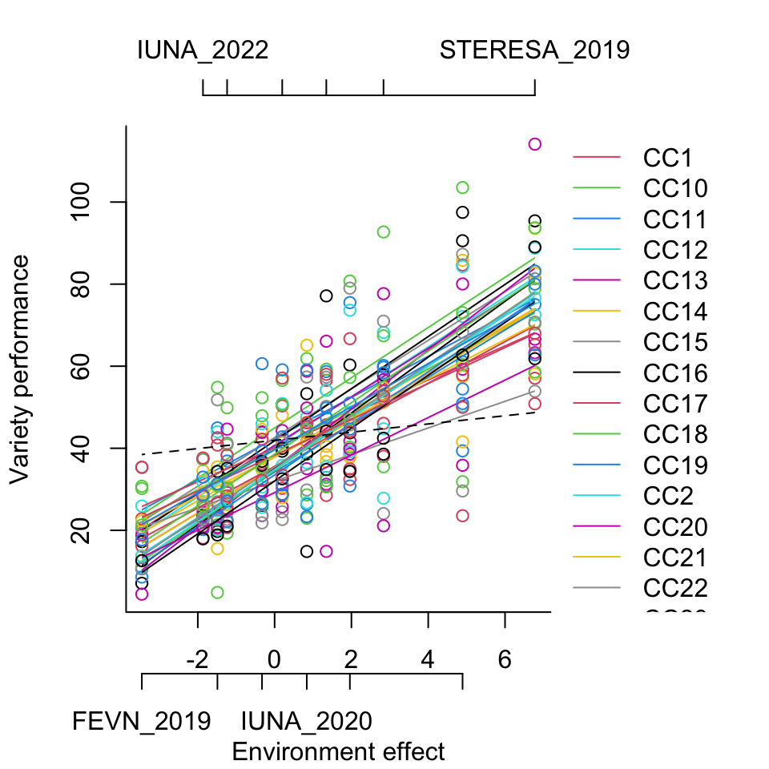

```r
plot.FW(lm1)
```

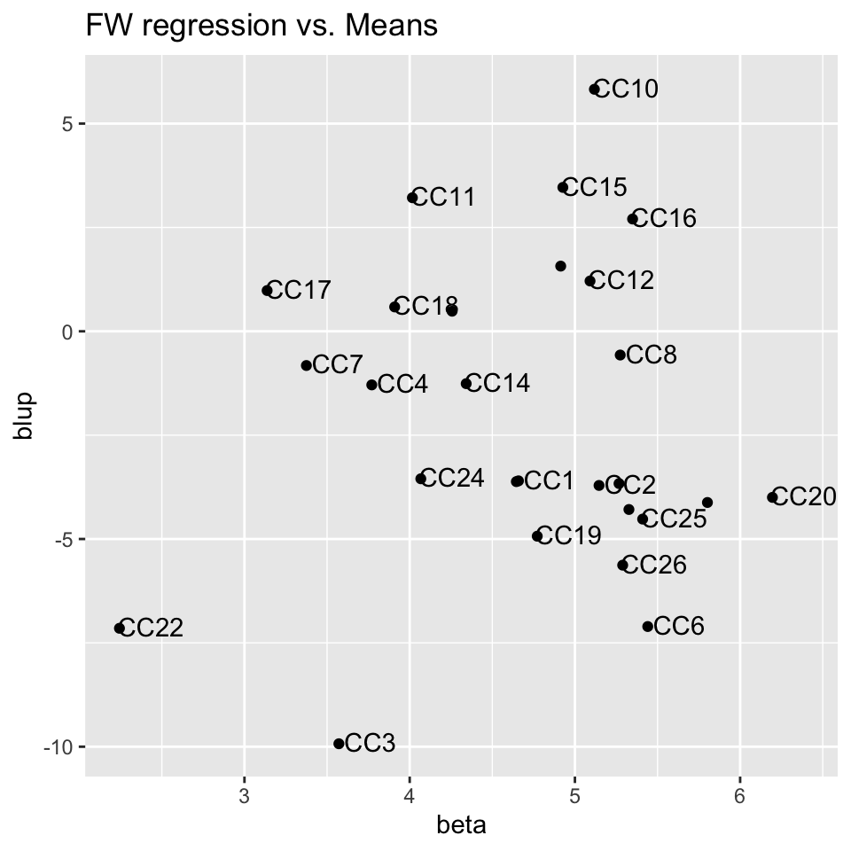

```r
# Plot
tmp = data.frame(genotype = rownames(lm1$g),blup = lm1$g,beta = lm1$b)
colnames(tmp) = c("Genotype", "blup", "beta")
ggplot(tmp, aes(x=beta, y=blup)) +
  geom_point() + # Show dots
  geom_text(
    label=tmp$Genotype,
    nudge_x = 0.19, nudge_y = 0.04,
    check_overlap = T
  ) + ggtitle("FW regression vs. Means")
```

## Extreme example

To check what exactly each method is doing, we modified the data set to represent a genotype (`CC1`) with broad adaptation; and a second a genotype with specific adaptation (`CC10`). To this end, we manipulated the original data set using the follow strategy:

- For the genotype `CC1` we included the same yield (40) across all environments.
- For the genotype `CC10` we assumed a large yield (average of 128 bags/hc) in the STERESA_2019 ennvironment.

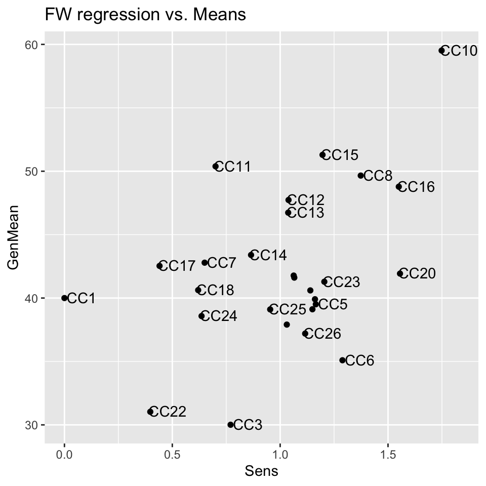

```r
# Classic FW regression
df = read.xlsx("/Users/lferrao/UFL Dropbox/Luis Ferrao/classes/QuantGen_24/Class11_GxE/coffee_27ind_canephora_12env.xlsx", sheet = 2)
dropsTD <- statgenSTA::createTD(data = df, genotype = "id", trial = "ENV")
dropsFW <- gxeFw(TD = dropsTD, trait = "YIELD")

library(ggplot2)
tmp = dropsFW$estimates
ggplot(tmp, aes(x=Sens, y=GenMean)) +
  geom_point() + # Show dots
  geom_text(
    label=tmp$Genotype,
    nudge_x = 0.08, nudge_y = 0.04,
    check_overlap = T
  ) + ggtitle("FW regression vs. Means")
```

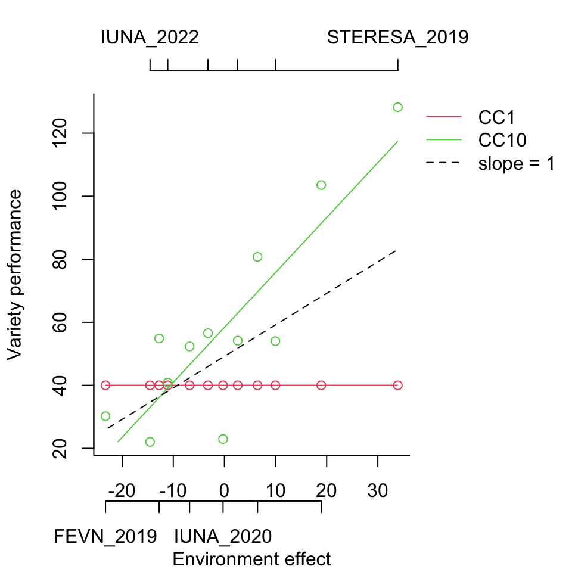

```r
# Bayesina version
# Download the phenotypic data and G matrix
df = read.xlsx("/Users/lferrao/UFL Dropbox/Luis Ferrao/classes/QuantGen_24/Class11_GxE/coffee_27ind_canephora_12env.xlsx",sheet = 2) %>%
group_by(id,ENV) %>%
summarise(avg = mean(YIELD,na.rm=T))

load("/Users/lferrao/UFL Dropbox/Luis Ferrao/classes/QuantGen_24/Class11_GxE/coffeeFW_GxE_Gmatrix_27ind.Rdata")

# FW regression
df3 = melt(df)
lm1 = FW(y=df3$value,VAR=df3$id, ENV = df3$ENV, method="OLS")
plot.FW(lm1,plotVAR = c("CC1","CC10"))
```

```r
head(lm1$b)
```

```
##             [,1]
## CC1  -1.00000000
## CC10  0.74237403
## CC11 -0.24760335
## CC12  0.03439734
## CC13  0.03133324
## CC14 -0.15646378
```

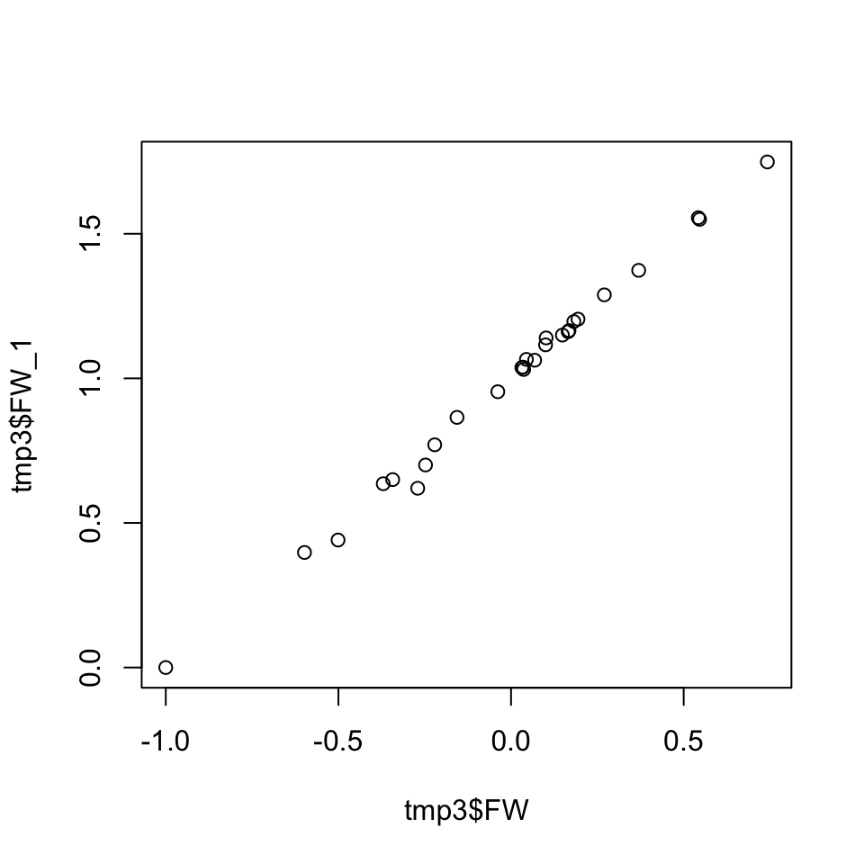

```r
# Comparing both results
tmp1 = data.frame(id=rownames(lm1$b), FW=lm1$b)
tmp2 = data.frame(id=dropsFW$estimates$Genotype, FW_1=dropsFW$estimates$Sens)
tmp3 = merge(tmp1,tmp2,by="id")
plot(tmp3$FW,tmp3$FW_1)
```

Some conclusions:

- Packages are suing different parametrizations for the sensitivity. In the Bayesian version, the slope close to -1 represent genotypes less sensibilities (or general adaptation) to the environmental change.
- In the traditional FW, slopes close to zero represent less sensibility.

# Final Considerations

The use of FW models aggregate some important elements:

1. easy to implement using any software or package;
2. straightforward visualization, that can help the interpretation of students and breeders;
3. valid results for decision-make.

# References

**Papers**

- Eeuwijk et al., 2016. What should students in plant breeding know about the statistical aspects of genotype × Environment interactions?. Crop Science. [Link for the paper](https://library.wur.nl/WebQuery/wurpubs/507495)
- Finlay and Wilkinson, 1963. The analysis of adaptation in a plant breeding programme. Australian Journal of Agricultural Research. [Link for the paper](https://www.publish.csiro.au/cp/ar9630742)
- Li and de los Campos, 2016. FW: An R Package for Finlay–Wilkinson Regression that Incorporates Genomic/Pedigree Information and Covariance Structures Between Environments. G3. [Link for the paper](https://www.g3journal.org/content/6/3/589)
- Malosetti et al., 2013. The statistical analysis of multi-environment data: modeling genotype-by-environment interaction and its genetic basis. Frontiers in Physiology. [Link for the paper](https://www.ncbi.nlm.nih.gov/pmc/articles/PMC3594989/)